# 2. Analysis of Price, Appraisal offers, Market, and Online appraisal flag

Sumit Kumar Kar

1/13/2023

# Relation between Appraisal offer and Price

```
## X
## $20k to $25k $25k to $30k $15k to $20k $30k to $35k $35k to $40k $40k to $45k
##      23.1940      20.2100      17.2885      14.2035      10.0380       5.3485
##   $0 to $15k $45k to $50k $50k to $55k $55k to $60k $60k to $65k        $70k+
##       4.4205       2.7195       1.2075       0.6525       0.2950       0.2430
## $65k to $70k
##       0.1795
```

```
## X
##  $00k to $5k $05k to $10k $10k to $15k $15k to $20k $20k to $25k $25k to $30k
##      34.5900      19.3440      14.1935      11.5510       8.3955       5.1870
## $30k to $35k        $40k+ $35k to $40k
##       3.0465       1.8475       1.8450
```

Contingency table between Appraisal offer and Price

```
##
##                $0 to $15k $15k to $20k $20k to $25k $25k to $30k $30k to $35k
##   $00k to $5k        6594        19995        18931        11944         6122
##   $05k to $10k        932         6303        10258         8796         5724
##   $10k to $15k        504         3222         6484         6560         4998
##   $15k to $20k        344         2246         4667         5399         4232
##   $20k to $25k        219         1326         2866         3631         3254
##   $25k to $30k        129          717         1430         2013         1886
##   $30k to $35k         59          401          824          987         1108
##   $35k to $40k         37          216          537          561          552
##   $40k+                23          151          391          529          531
##
##                $35k to $40k $40k to $45k $45k to $50k $50k to $55k $55k to $60k
##   $00k to $5k          3326         1395          515          212           85
##   $05k to $10k         3625         1717          804          281          134
##   $10k to $15k         3481         1699          796          328          182
##   $15k to $20k         3153         1618          778          330          163
##   $20k to $25k         2581         1447          788          337          172
##   $25k to $30k         1787         1147          640          309          145
##   $30k to $35k          994          729          445          240          147
##   $35k to $40k          593          490          306          150          110
##   $40k+                 536          455          367          228          167
##
##                $60k to $65k $65k to $70k $70k+
##   $00k to $5k            31           14    16
##   $05k to $10k           55           33    26
##   $10k to $15k           69           36    28
##   $15k to $20k           77           49    46
##   $20k to $25k           82           31    57
##   $25k to $30k           77           44    50
##   $30k to $35k           56           35    68
##   $35k to $40k           43           38    57
##   $40k+                 100           79   138
```

Heat map between Appraisal offer and Price

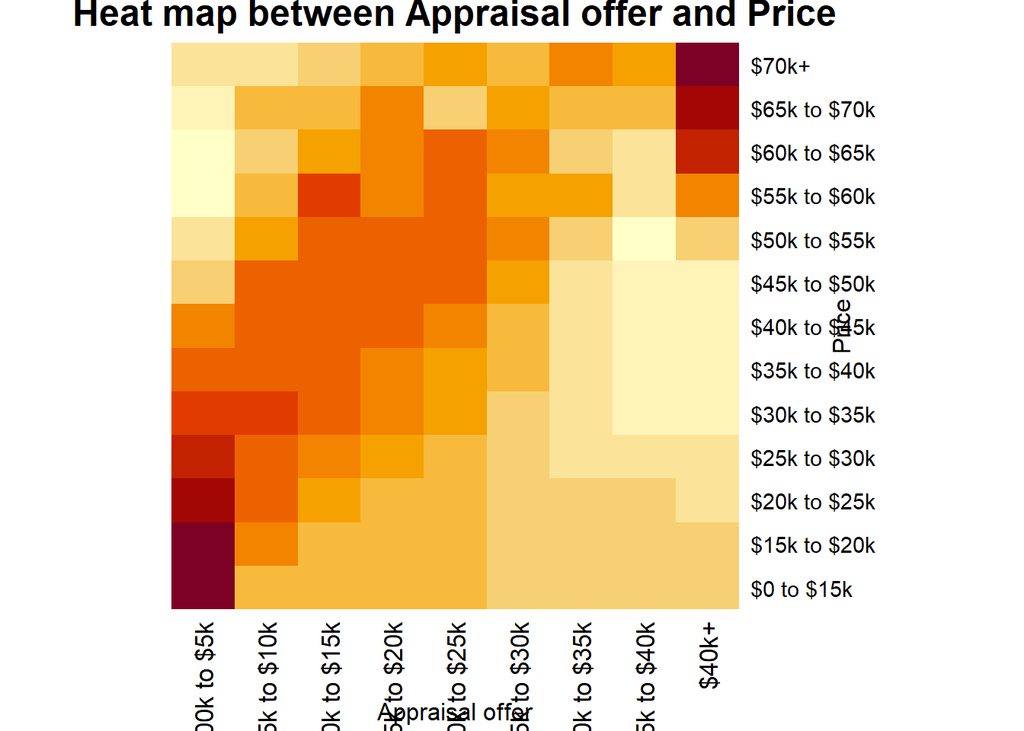

We can see that price of purchased cars increases with appraised values.

Chi-squared test between Appraisal offer and Price

```r
chisq.test(derived_data$price, derived_data$appraisal_offer1)
```

```
##
##  Pearson's Chi-squared test
##
## data:  derived_data$price and derived_data$appraisal_offer1
## X-squared = 41103, df = 96, p-value < 2.2e-16
```

The p-value is very small, which implies that Appraisal offer and Price are dependent.

# Relation between Market and Price/Appraisal offer

Let us see the percentage of transactions done in each market (in decreasing order).

```
## X
##     14      8      4     10     11      1      7      9      5     16      2
## 9.8645 8.1955 8.1275 7.4640 7.1935 7.0330 7.0015 6.8315 6.5385 5.9350 5.8645
##      6     15     12      3     13
## 5.7085 4.9945 3.6660 3.0735 2.5085
```

The above table shows that the maximum number of transactions takes place in Market 14 and the minimum in Market 13.

Contingency table between Market and Price

```
##
##      $0 to $15k $15k to $20k $20k to $25k $25k to $30k $30k to $35k
##   1         585         2460         3231         2752         2076
##   2         481         1965         2766         2478         1679
##   3         292         1062         1480         1304          845
##   4         610         2739         3873         3328         2377
##   5         563         2463         3328         2710         1767
##   6         377         2077         2652         2270         1626
##   7         690         2429         3148         2763         1931
##   8         751         2975         3964         3328         2210
##   9         438         2164         2991         2793         2084
##   10        761         2632         3426         2974         2123
##   11        514         2389         3362         2849         2067
##   12        301         1211         1645         1504         1050
##   13        279          949         1198         1038          666
```

[output cut: 39 more lines]

Heat map between Market and Price

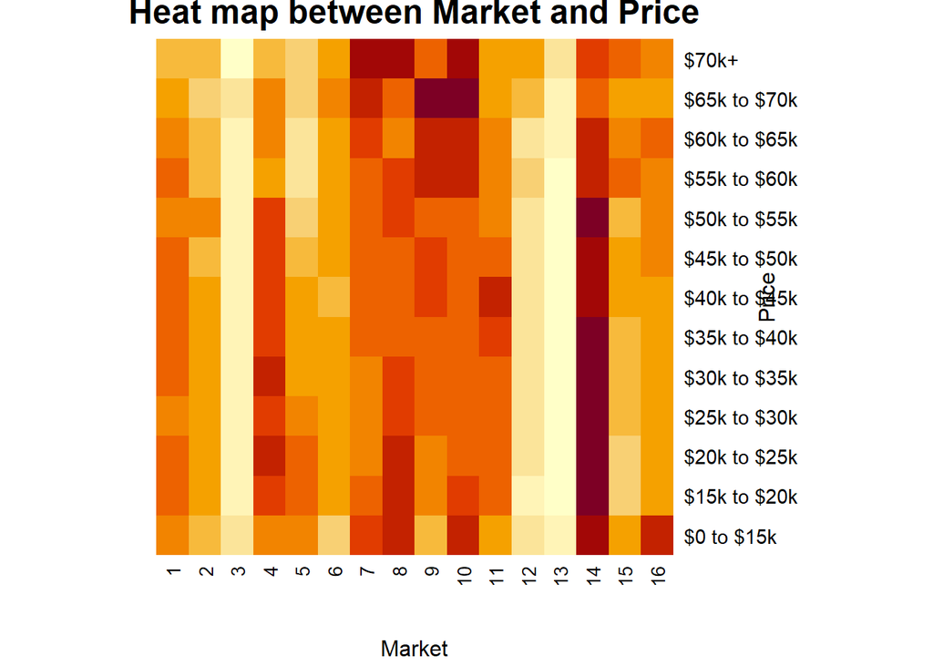

Chi-squared test between Market and Price

```r
chisq.test(derived_data$price, derived_data$market)
```

```
##
##  Pearson's Chi-squared test
##
## data:  derived_data$price and derived_data$market
## X-squared = 1022.3, df = 180, p-value < 2.2e-16
```

The p-value is very small, which implies that Market and Price are dependent.

Contingency table between Market and Appraisal offer

```
##
##      $00k to $5k $05k to $10k $10k to $15k $15k to $20k $20k to $25k
##   1         4727         2703         1998         1695         1226
##   2         4389         2371         1648         1278          890
##   3         2354         1111          829          727          461
##   4         5542         3069         2365         1928         1383
##   5         5555         2425         1718         1304          938
##   6         3427         2184         1598         1352         1131
##   7         4891         2679         1949         1634         1121
##   8         5404         3043         2326         2017         1421
##   9         3490         2711         2070         1764         1467
##   10        5190         3009         2133         1740         1208
##   11        5096         2798         2009         1618         1172
##   12        2340         1472         1076          902          650
##   13        1864          984          692          543          421
```

[output cut: 21 more lines]

Heat map between Market and Appraisal offer

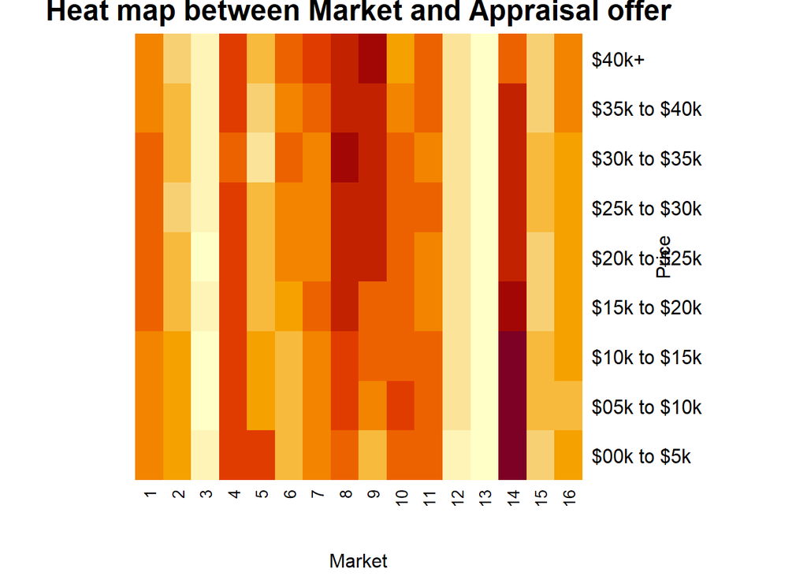

Chi-squared test between Market and Appraisal offer

```r
chisq.test(derived_data$appraisal_offer1, derived_data$market)
```

```
##
##  Pearson's Chi-squared test
##
## data:  derived_data$appraisal_offer1 and derived_data$market
## X-squared = 1758.3, df = 120, p-value < 2.2e-16
```

The p-value is very small, which implies that Market and Appraisal offer are dependent.

# Relation between Online appraisal flag and Price/Appraisal offer

Let us see the percentages of transactions done online vs. in-person

```
## X
##      0      1   null
## 73.273 24.810  1.917
```

The above table shows that 73% of the transactions took place in-person and 25% online. Let us make bar plots to check the price and appraisal offer for two types of transactions (we will exclude the null values, i.e., for which online/in-person is not known).

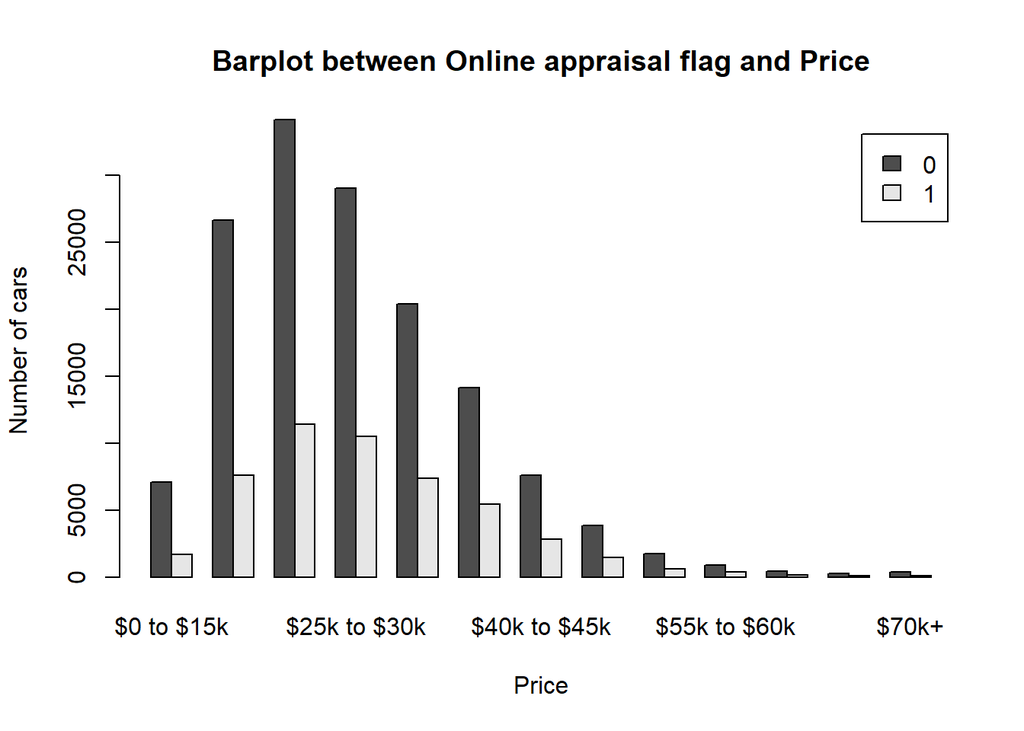

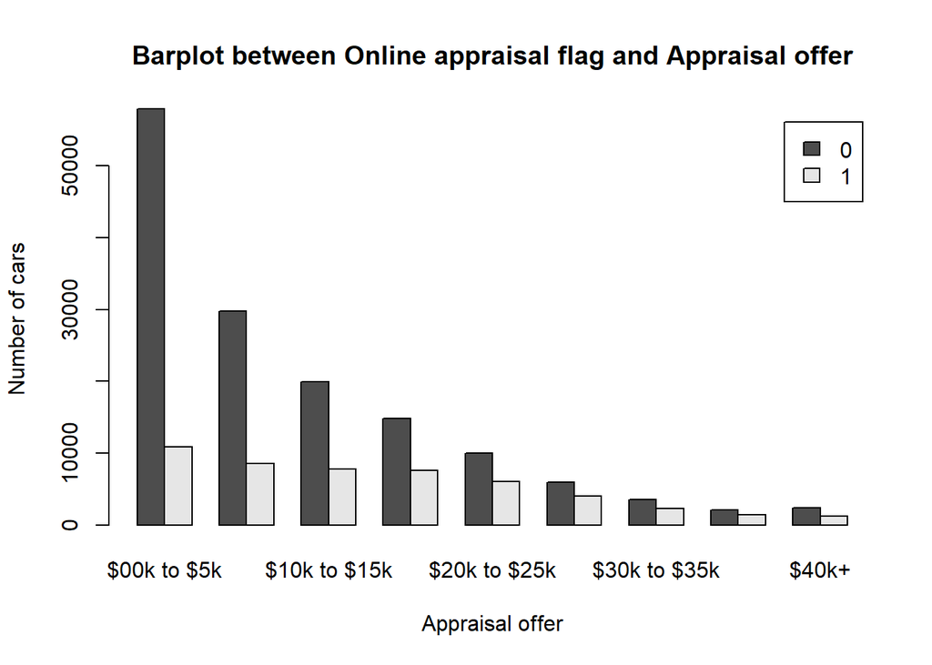

The above bar plot shows that for cars of each price range and each appraisal offer range, more transactions occur in-person compared to online.

Chi-squared tests between Online appraisal flag and Price/Appraisal offer

```r
chisq.test(derived_data$price, derived_data$online_appraisal_flag)
```

```
##
##  Pearson's Chi-squared test
##
## data:  derived_data$price and derived_data$online_appraisal_flag
## X-squared = 876.21, df = 24, p-value < 2.2e-16
```

```r
chisq.test(derived_data$appraisal_offer1, derived_data$online_appraisal_flag)
```

```
##
##  Pearson's Chi-squared test
##
## data:  derived_data$appraisal_offer1 and derived_data$online_appraisal_flag
## X-squared = 10004, df = 16, p-value < 2.2e-16
```

The p-values are very small, which implies that both Price and Appraisal offer are dependent on Online appraisal flag.

# Relation between Online appraisal flag and Market

Let us make bar plots to check the two types of transactions in each market (we will exclude the null values, i.e., for which online/in-person is not known).

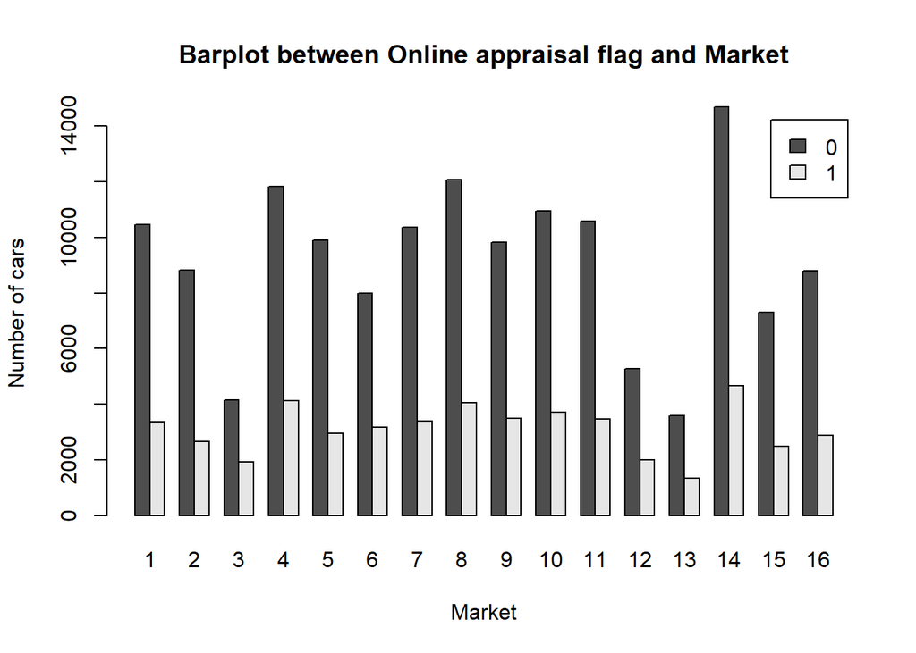

The above bar plot shows that in each market, more transactions occur in-person compared to online.

Chi-squared test between Online appraisal flag and Market

```r
chisq.test(derived_data$market, derived_data$online_appraisal_flag)
```

```
##
##  Pearson's Chi-squared test
##
## data:  derived_data$market and derived_data$online_appraisal_flag
## X-squared = 447.63, df = 30, p-value < 2.2e-16
```